# Lab 6

Damodar Pai

2024-03-01

# Tasks

## Task 1

```r
getwd()
```

```
## [1] "/Users/damodarpai/Documents/Labratories/Lab6"
```

## Task 2

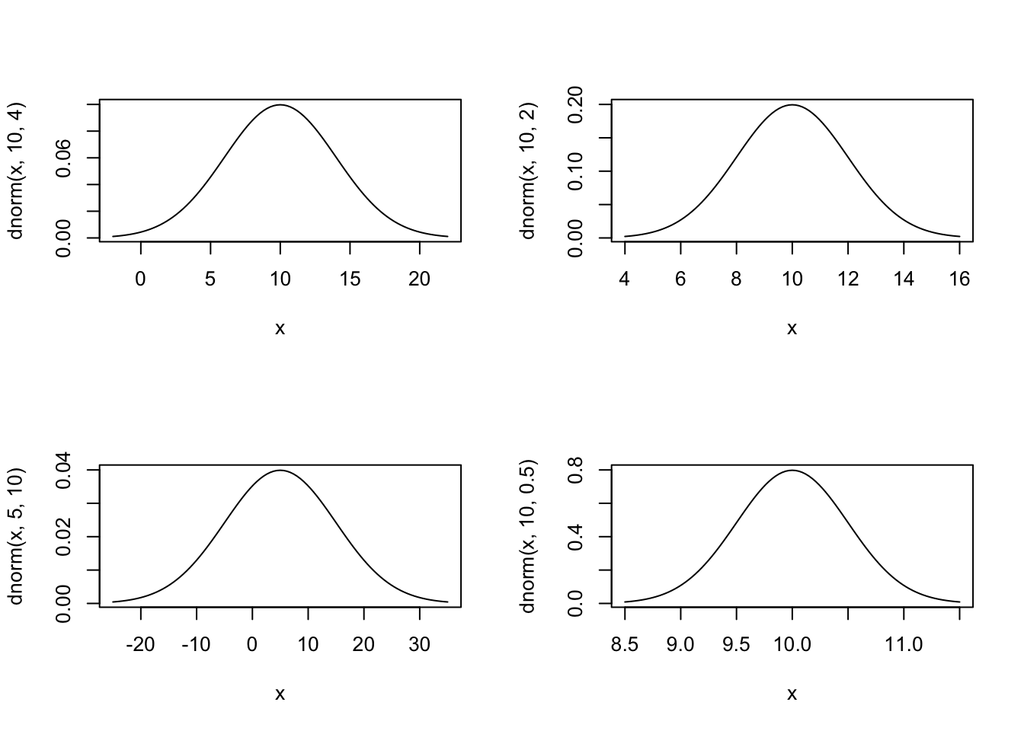

```r
layout_matrix <- matrix(c(1, 2, 3, 4), nrow = 2, byrow = TRUE)

# Set the layout
layout(layout_matrix)

x <- NULL
curve(dnorm(x, 10, 4), xlim = c(10 - 3*4, 10 + 3*4))
curve(dnorm(x, 10, 2), xlim = c(10 - 3*2, 10 + 3*2))
curve(dnorm(x, 5, 10), xlim = c(5 - 3*10, 5 + 3*10))
curve(dnorm(x, 10, 0.5), xlim = c(10 - 3*0.5, 10 + 3*0.5))
```

### For the above plots, we’re plotting the normal functions with the above given characteristics related to mean and standard deviation. Note the spread and center are different based on these characteristics for each graph.

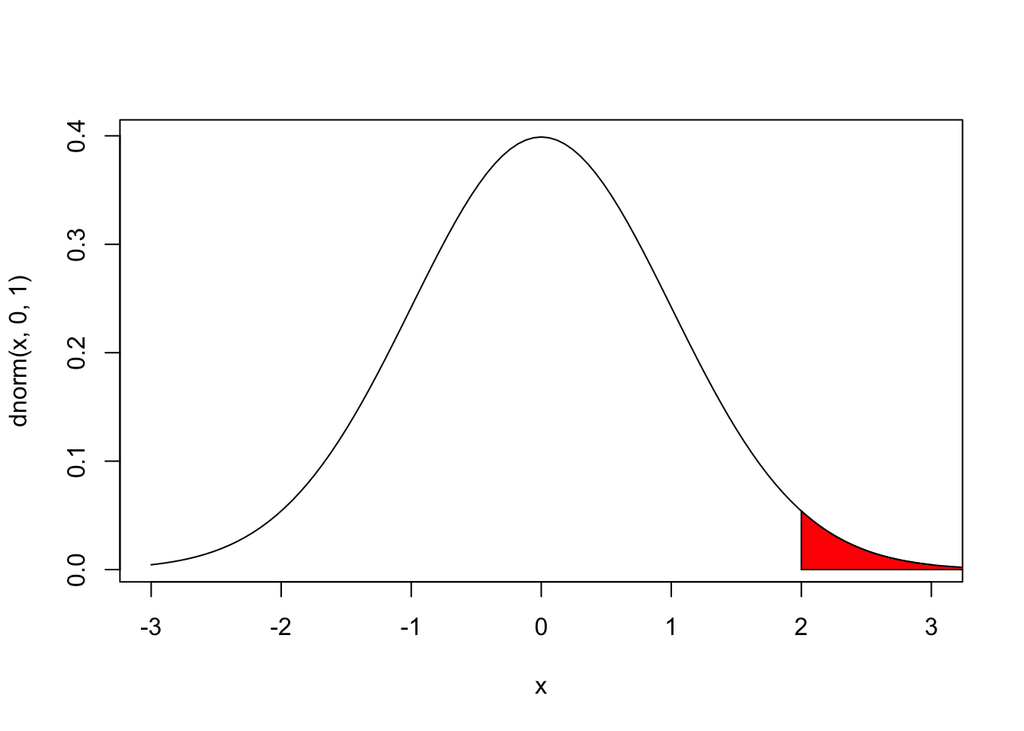

```r
x <- NULL
curve(dnorm(x, 0, 1), xlim = c(0 - 3*1, 0 + 3*1))

# Define the range of the area to highlight
xcurve <- seq(2, 10, length = 1000)

# Calculate the density of the normal distribution for this range
ycurve <- dnorm(xcurve, 0, 1)


polygon(c(2, xcurve, 10), c(0, ycurve, 0), col = "red")
```

```r
# Calculate the Area
area = pnorm(10, 0, 1) - pnorm(2, 0, 1)
area
```

```
## [1] 0.02275013
```

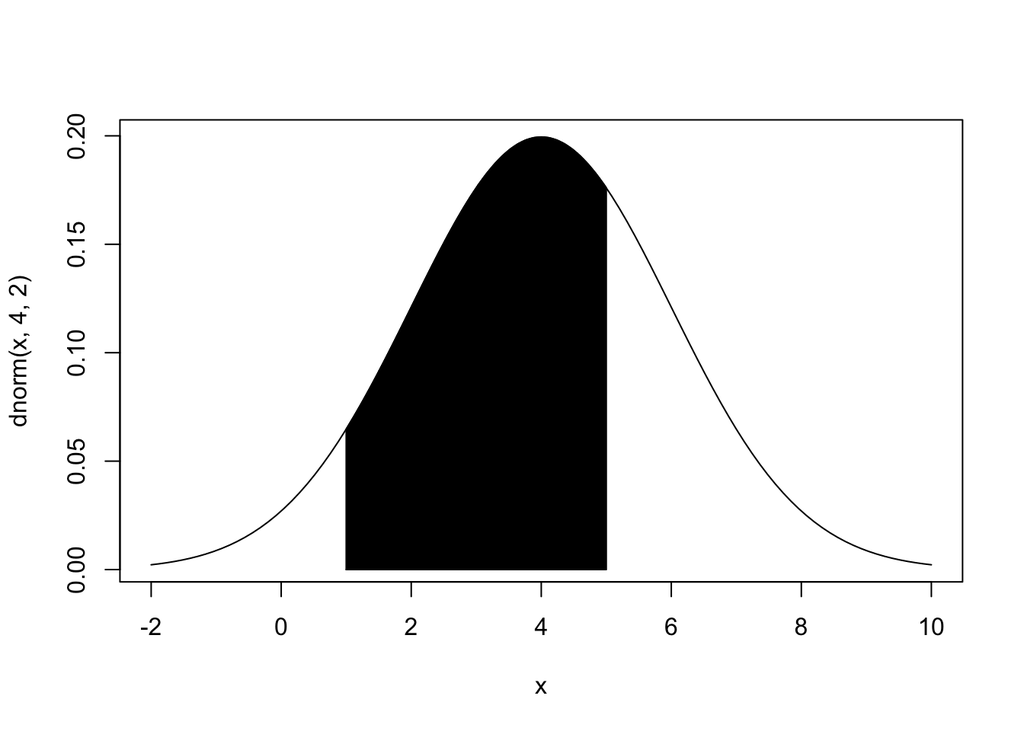

```r
x <- NULL
curve(dnorm(x, 4, 2), xlim = c(4 - 3*2, 4 + 3*2))

# Define the range of the area to highlight
xcurve <- seq(1, 5, length = 1000)

# Calculate the density of the normal distribution for this range
ycurve <- dnorm(xcurve, 4, 2)


polygon(c(1, xcurve, 5), c(0, ycurve, 0), col = "black")
```

```r
# Calculate the Area
area = pnorm(5, 4, 2) - pnorm(1, 4, 2)
area
```

```
## [1] 0.6246553
```

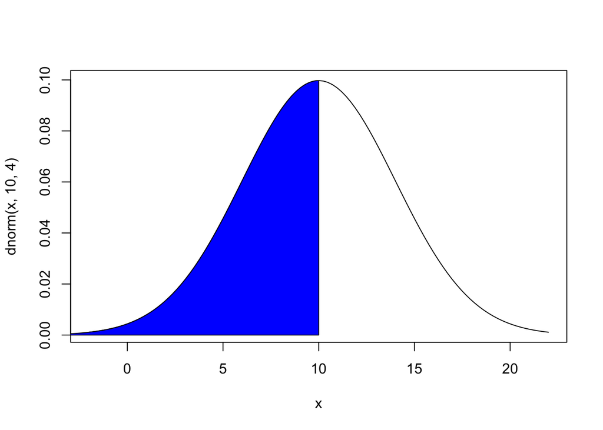

```r
x <- NULL
curve(dnorm(x, 10, 4), xlim = c(10 - 3*4, 10 + 3*4))

# Define the range of the area to highlight
xcurve <- seq(-20, 10, length = 1000)

# Calculate the density of the normal distribution for this range
ycurve <- dnorm(xcurve, 10, 4)


polygon(c(-20, xcurve, 10), c(0, ycurve, 0), col = "blue")
```

```r
# Calculate the Area
area = pnorm(10, 10, 4) - pnorm(-20, 10, 4)
area
```

```
## [1] 0.5
```

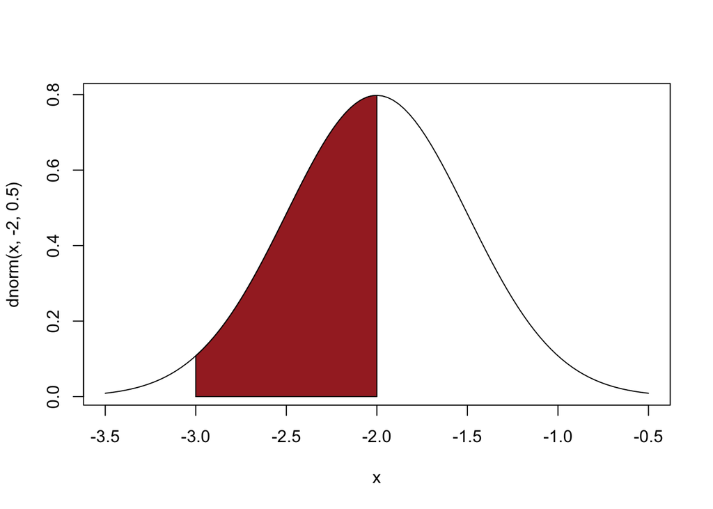

```r
x <- NULL
curve(dnorm(x, -2, 0.5), xlim = c(-2 - 3*0.5, -2 + 3*0.5))

# Define the range of the area to highlight
xcurve <- seq(-3, -2, length = 1000)

# Calculate the density of the normal distribution for this range
ycurve <- dnorm(xcurve, -2, 0.5)


polygon(c(-3, xcurve, -2), c(0, ycurve, 0), col = "brown")
```

```r
# Calculate the Area
area = pnorm(-2, -2, 0.5) - pnorm(-3, -2, 0.5)
area
```

```
## [1] 0.4772499
```

## Task 3

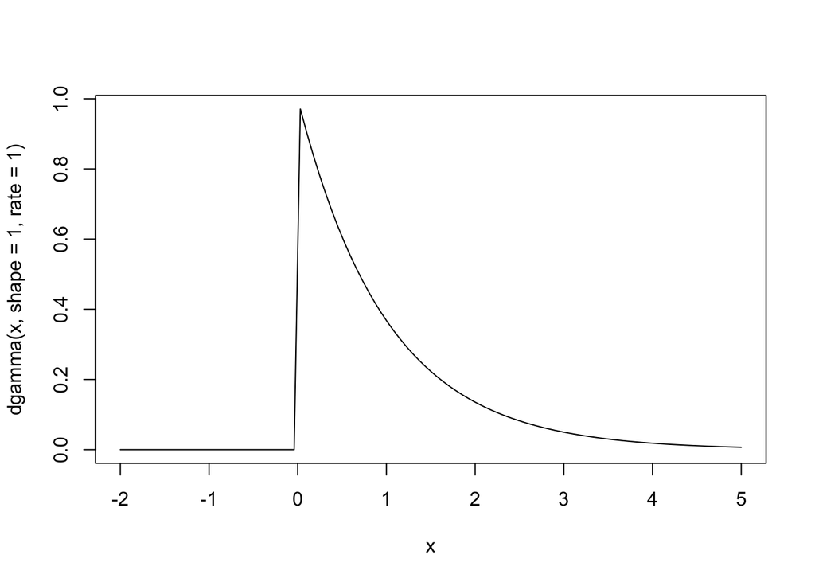

```r
x <- NULL
curve(dgamma(x,shape=1,rate=1),xlim = c(-2,5))
```

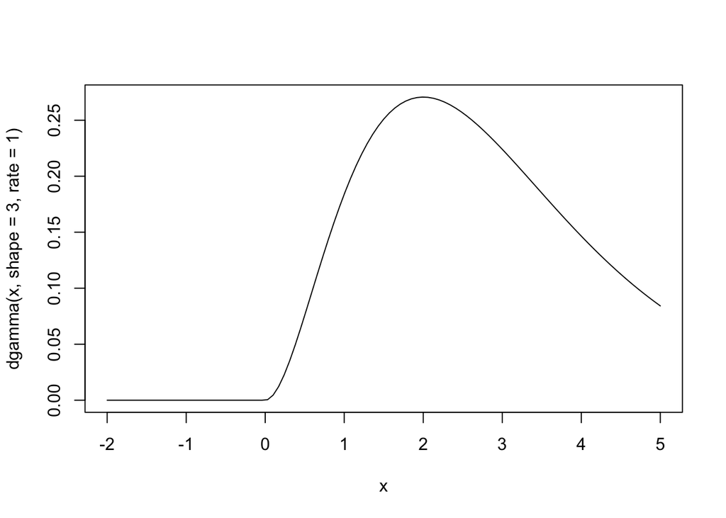

```r
curve(dgamma(x,shape=3,rate=1),xlim = c(-2,5))
```

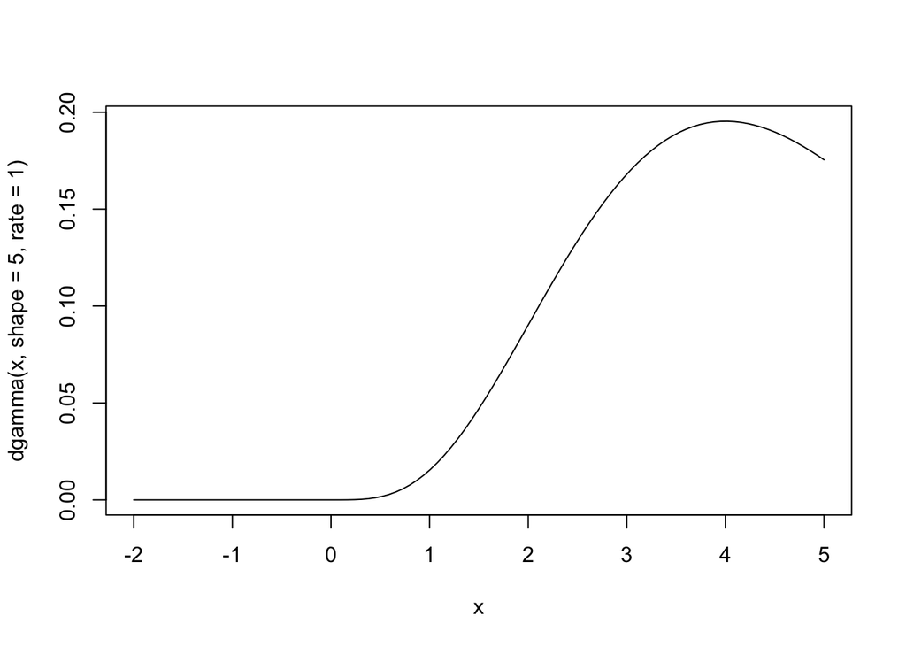

```r
curve(dgamma(x,shape=5,rate=1),xlim = c(-2,5))
```

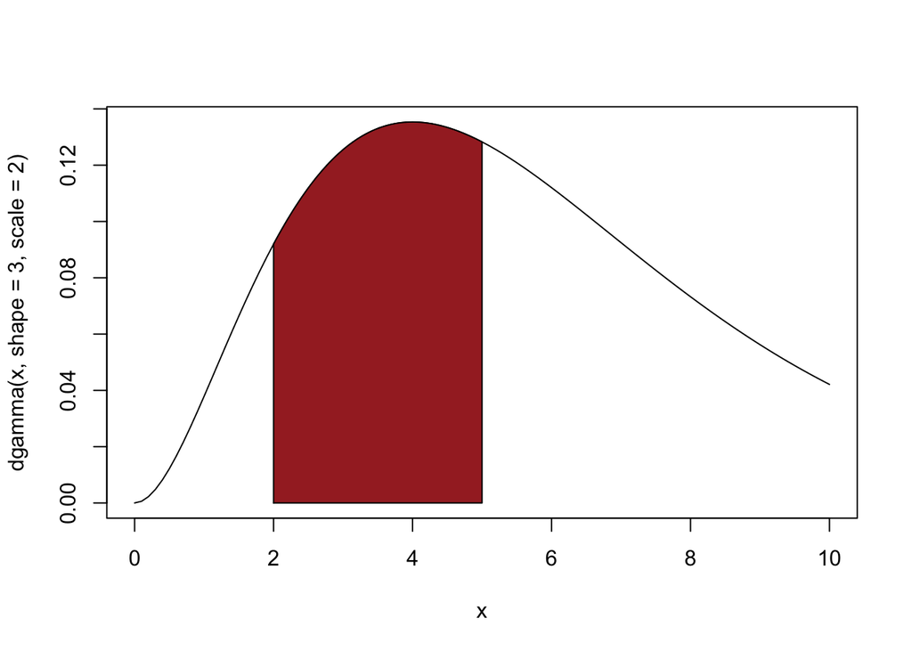

```r
x <- NULL
curve(dgamma(x, shape=3, scale = 2), xlim = c(0,10))

# Define the range of the area to highlight
xcurve <- seq(2, 5, length = 1000)

# Calculate the density of the normal distribution for this range
ycurve <- dgamma(xcurve, 3, scale = 2)


polygon(c(2, xcurve, 5), c(0, ycurve, 0), col = "brown")
```

```r
# Calculate the Area
area = pgamma(5, 3, scale = 2) - pgamma(2, 3, scale = 2)
area
```

```
## [1] 0.3758855
```

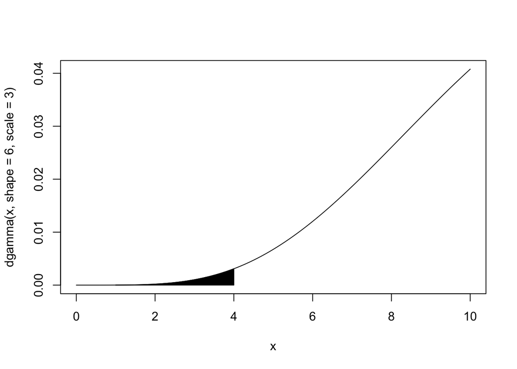

```r
x <- NULL
curve(dgamma(x, shape=6, scale = 3), xlim = c(0,10))

# Define the range of the area to highlight
xcurve <- seq(1, 4, length = 1000)

# Calculate the density of the normal distribution for this range
ycurve <- dgamma(xcurve, 6, scale = 3)


polygon(c(1, xcurve, 4), c(0, ycurve, 0), col = "black")
```

```r
# Calculate the Area
area = pgamma(4, 6, scale = 3) - pgamma(1, 6, scale = 3)
area
```

```
## [1] 0.002523855
```

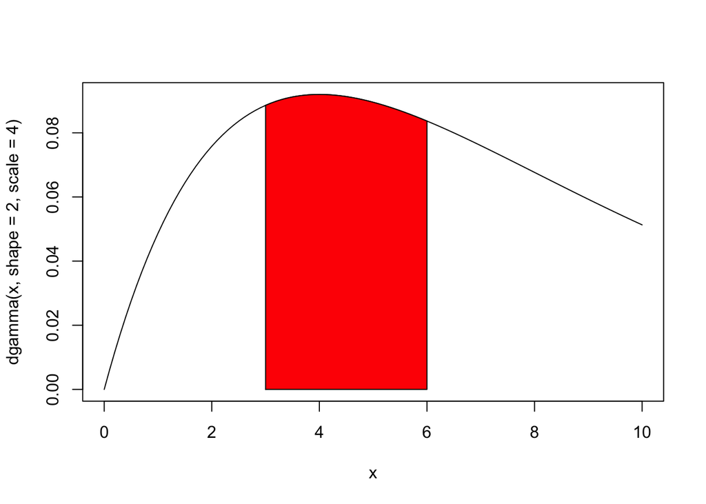

```r
x <- NULL
curve(dgamma(x, shape=2, scale=4), xlim = c(0,10))

# Define the range of the area to highlight
xcurve <- seq(3, 6, length = 1000)

# Calculate the density of the normal distribution for this range
ycurve <- dgamma(xcurve, 2, scale = 4)


polygon(c(3, xcurve, 6), c(0, ycurve, 0), col = "red")
```

```r
# Calculate the Area
area = pgamma(6, 2, scale = 4) - pgamma(3, 2, scale = 4)
area
```

```
## [1] 0.2688161
```

## Task 4

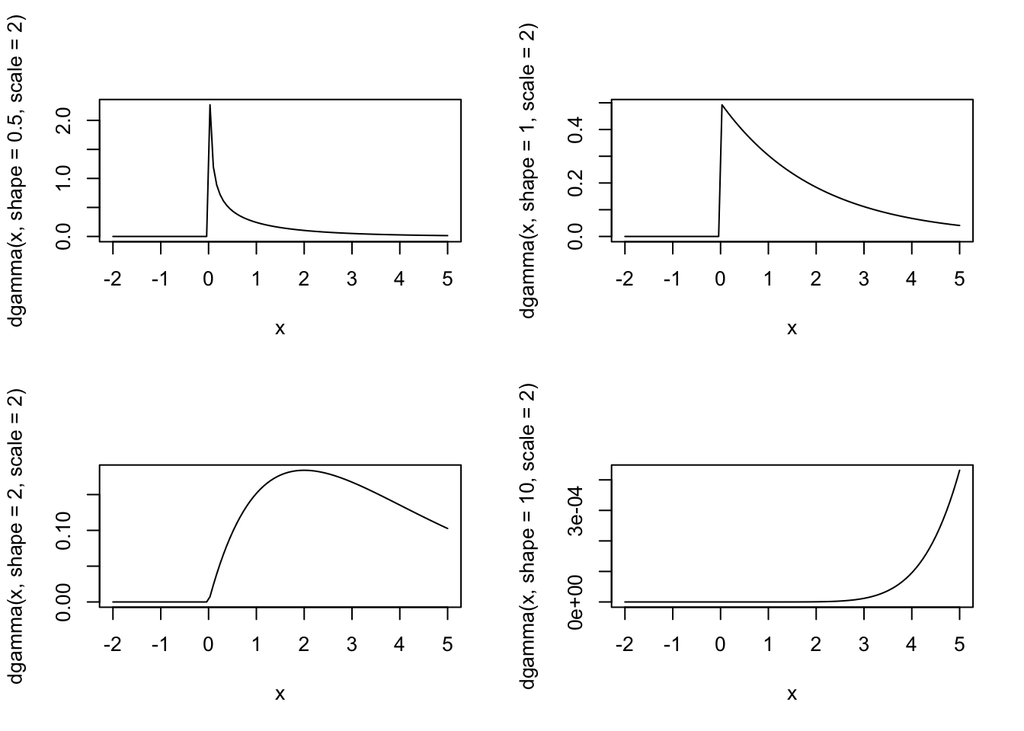

```r
layout_matrix <- matrix(c(1, 2, 3, 4), nrow = 2, byrow = TRUE)

# Set the layout
layout(layout_matrix)

x <- NULL
curve(dgamma(x,shape=0.5,scale=2),xlim = c(-2,5))
curve(dgamma(x,shape=1,scale=2),xlim = c(-2,5))
curve(dgamma(x,shape=2,scale=2),xlim = c(-2,5))
curve(dgamma(x,shape=10,scale=2),xlim = c(-2,5))
```

### The below curves plot the chi-square function given the densities of each x value with the given shape(alpha) and scale(Beta). The chi-square plots are special type of gamma function because they always have scale equal to 2. We then make a polygon that’s colored red with x values from a certain width(depending on the probabilities), and then relate those x to the corresponding y. We start the y at 0 and end at 0 since at each point, the area of that slit is going to be 0. We can calculate the total area by simply using pgamma which doesn’t reference our graph but essentially finds the probability that data falls into a certain part of the graph.

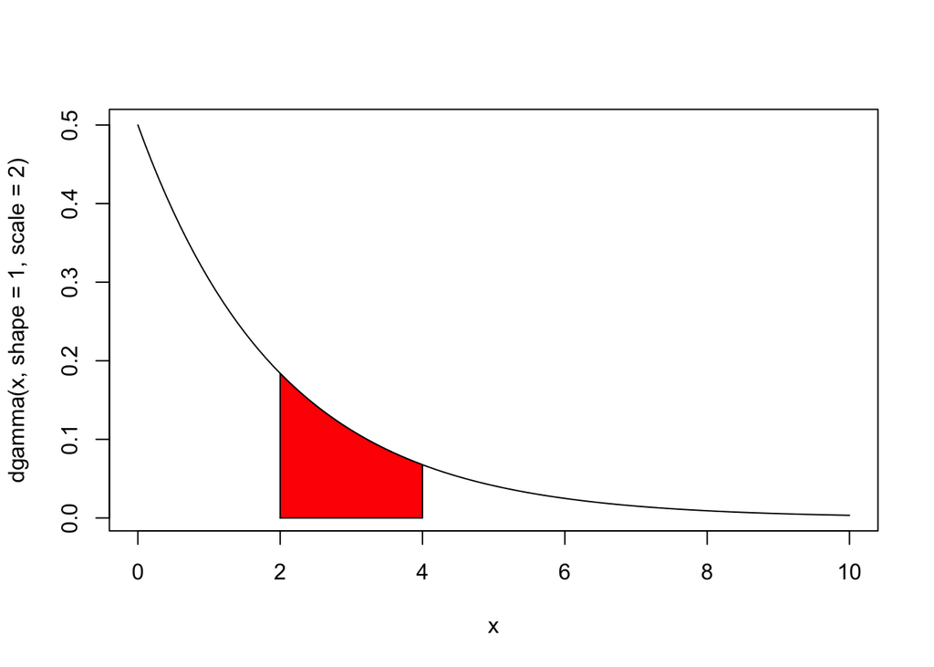

```r
x <- NULL
curve(dgamma(x, shape=1, scale=2), xlim = c(0,10))


xcurve <- seq(2, 4, length = 1000)


ycurve <- dgamma(xcurve, 1, scale = 2)


polygon(c(2, xcurve, 4), c(0, ycurve, 0), col = "red")
```

```r
area = pgamma(4, 1, scale = 2) - pgamma(2, 1, scale = 2)
area
```

```
## [1] 0.2325442
```

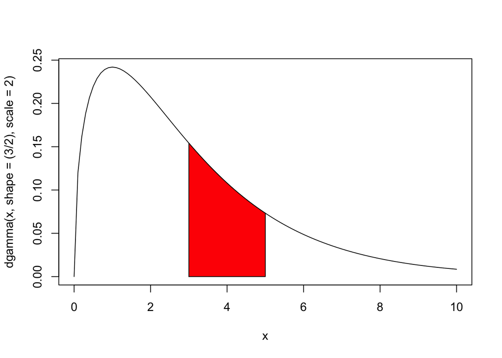

```r
x <- NULL
curve(dgamma(x, shape=(3/2), scale=2), xlim = c(0,10))


xcurve <- seq(3, 5, length = 1000)

# Calculate the density of the normal distribution for this range
ycurve <- dgamma(xcurve, (3/2), scale = 2)


polygon(c(3, xcurve, 5), c(0, ycurve, 0), col = "red")
```

```r
# Calculate the Area
area = pgamma(5, (3/2), scale = 2) - pgamma(3, (3/2), scale = 2)
area
```

```
## [1] 0.219828
```

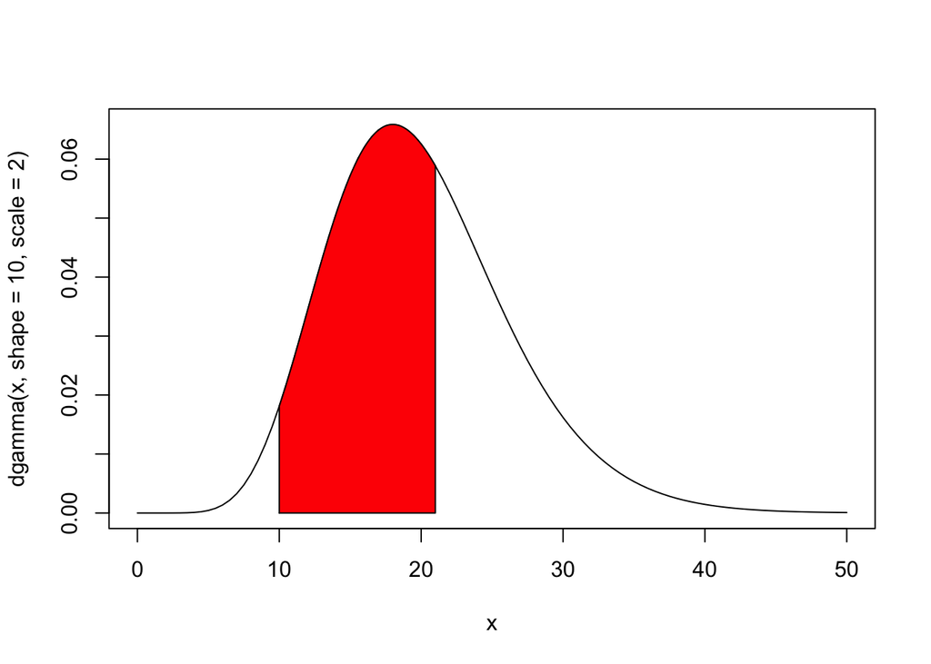

```r
x <- NULL
curve(dgamma(x, shape=10, scale=2), xlim = c(0,50))

# Define the range of the area to highlight
xcurve <- seq(10, 21, length = 1000)

# Calculate the density of the normal distribution for this range
ycurve <- dgamma(xcurve, 10, scale = 2)


polygon(c(10, xcurve, 21), c(0, ycurve, 0), col = "red")
```

```r
# Calculate the Area
area = pgamma(21, 10, scale = 2) - pgamma(10, 10, scale = 2)
area
```

```
## [1] 0.5710393
```

## Task 5

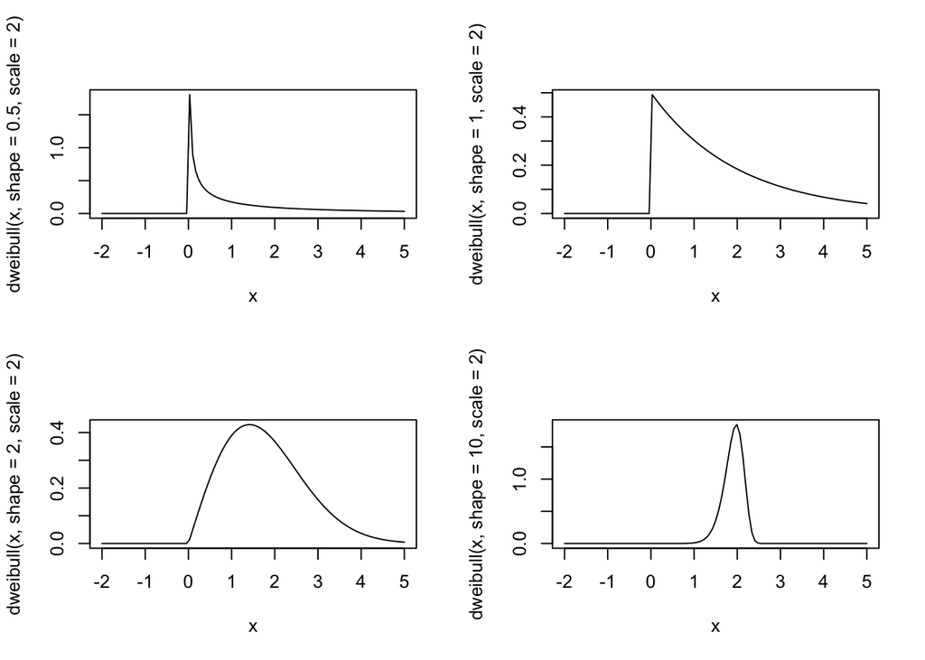

```r
layout_matrix <- matrix(c(1, 2, 3, 4), nrow = 2, byrow = TRUE)

# Set the layout
layout(layout_matrix)

x <- NULL
curve(dweibull(x,shape=0.5,scale=2),xlim = c(-2,5))
curve(dweibull(x,shape=1,scale=2),xlim = c(-2,5))
curve(dweibull(x,shape=2,scale=2),xlim = c(-2,5))
curve(dweibull(x,shape=10,scale=2),xlim = c(-2,5))
```

### The below curves plot the weibull function given the densities of each x value with the given shape(alpha) and scale(Beta). Weibull function is not related to the gamma function but is useful in modeling failure times, an example of this is failure of machinery. We then make a polygon that’s colored red with x values from a certain width(depending on the probabilities), and then relate those x to the corresponding y. We start the y at 0 and end at 0 since at each point, the area of that slit is going to be 0. We can calculate the total area by simply using pweibull which doesn’t reference our graph but essentially finds the probability that data falls into a certain part of the graph.

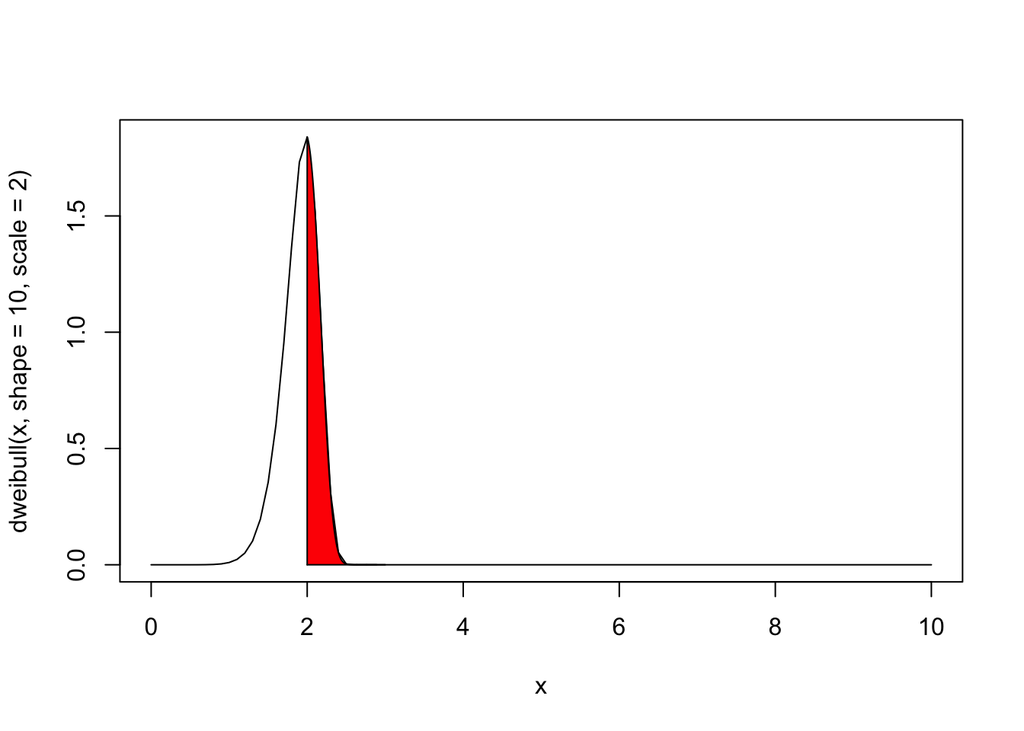

```r
x <- NULL
curve(dweibull(x, shape=10, scale=2), xlim = c(0,10))

# Define the range of the area to highlight
xcurve <- seq(2, 3, length = 1000)

# Calculate the density of the normal distribution for this range
ycurve <- dweibull(xcurve, 10, scale = 2)


polygon(c(2, xcurve, 3), c(0, ycurve, 0), col = "red")
```

```r
# Calculate the Area
area = pweibull(3, 10, scale = 2) - pweibull(2, 10, scale = 2)
area
```

```
## [1] 0.3678794
```

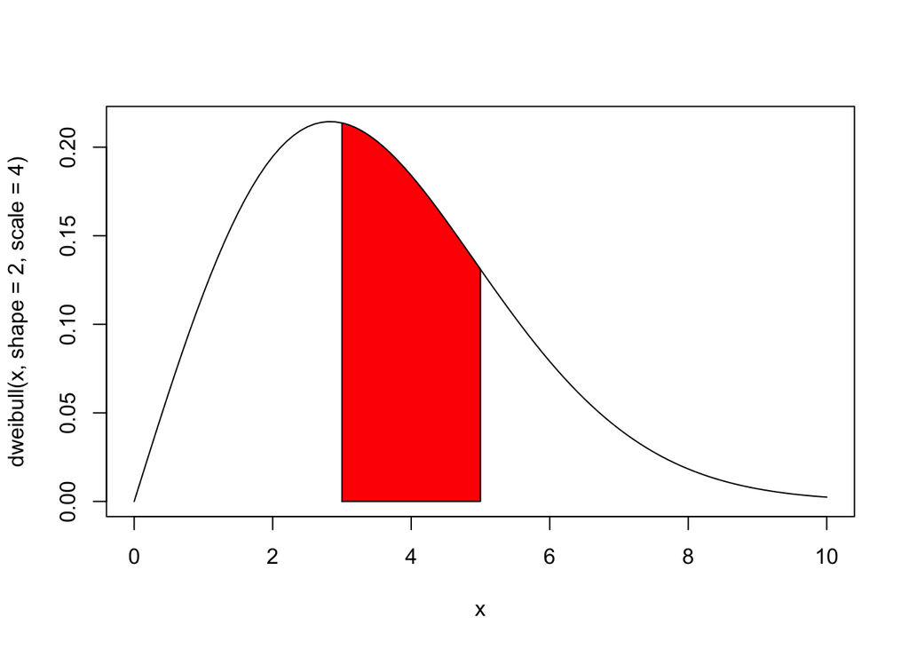

```r
x <- NULL
curve(dweibull(x, shape=2, scale=4), xlim = c(0,10))

# Define the range of the area to highlight
xcurve <- seq(3, 5, length = 1000)

# Calculate the density of the normal distribution for this range
ycurve <- dweibull(xcurve, 2, scale = 4)


polygon(c(3, xcurve, 5), c(0, ycurve, 0), col = "red")
```

```r
# Calculate the Area
area = pweibull(5, 2, scale = 4) - pweibull(3, 2, scale = 4)
area
```

```
## [1] 0.3601714
```

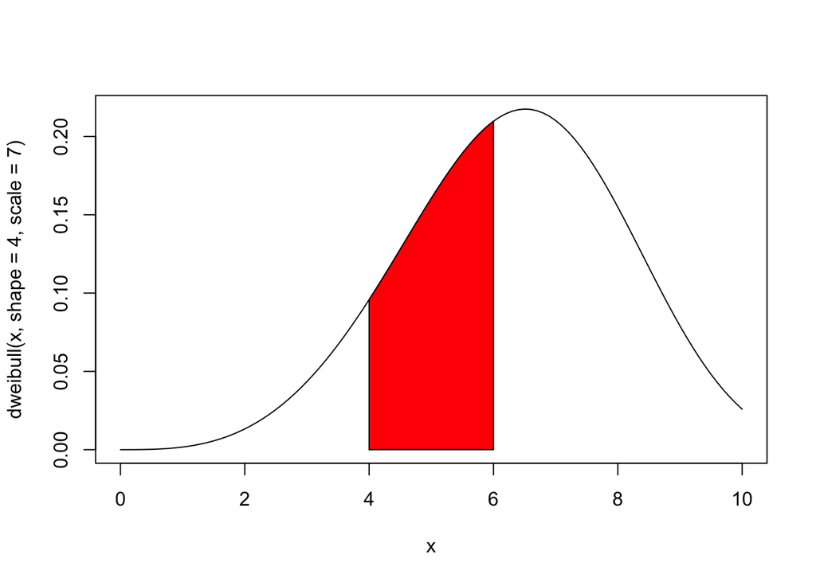

```r
x <- NULL
curve(dweibull(x, shape=4, scale=7), xlim = c(0,10))

# Define the range of the area to highlight
xcurve <- seq(4, 6, length = 1000)

# Calculate the density of the normal distribution for this range
ycurve <- dweibull(xcurve, 4, scale = 7)


polygon(c(4, xcurve, 6), c(0, ycurve, 0), col = "red")
```

```r
# Calculate the Area
area = pweibull(6, 4, scale = 7) - pweibull(4, 4, scale = 7)
area
```

```
## [1] 0.3159858
```

## Task 6

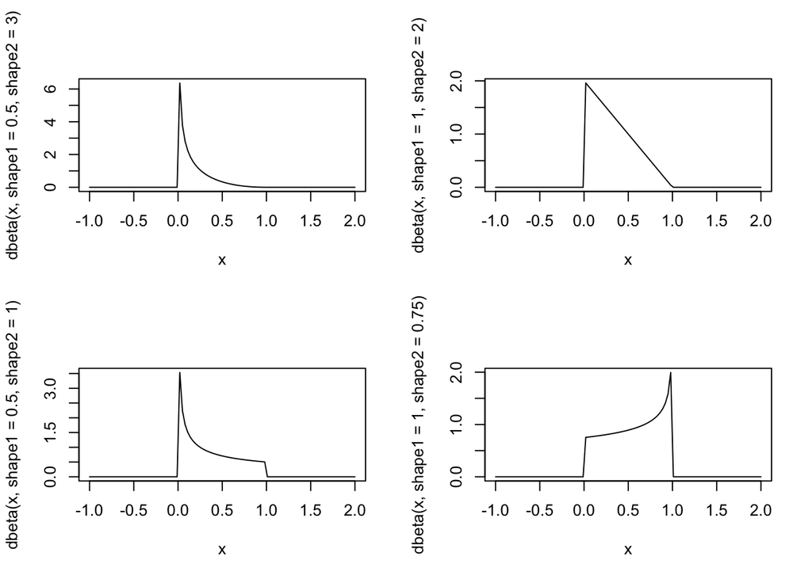

```r
?dbeta
x <- NULL

layout_matrix <- matrix(c(1, 2, 3, 4), nrow = 2, byrow = TRUE)

# Set the layout
layout(layout_matrix)
curve(dbeta(x,shape1=0.5,shape2=3),xlim = c(-1,2))
curve(dbeta(x,shape1=1,shape2=2),xlim = c(-1,2))
curve(dbeta(x,shape1=0.5,shape2=1),xlim = c(-1,2))
curve(dbeta(x,shape1=1,shape2=0.75),xlim = c(-1,2))
```

### The below curves plot the beta function given the densities of each x value with the given shape1 and shape2. The beta function tends to be used for probabilities because it is within the range of 0 and 1. We then make a polygon that’s colored red with x values from a certain width(depending on the probabilities) but must be betwee 0 and 1, and then relate those x to the corresponding y. We start the y at 0 and end at 0 since at each point, the area of that slit is going to be 0. We can calculate the total area by simply using pbeta which doesn’t reference our graph but essentially finds the probability that data falls into a certain part of the graph.

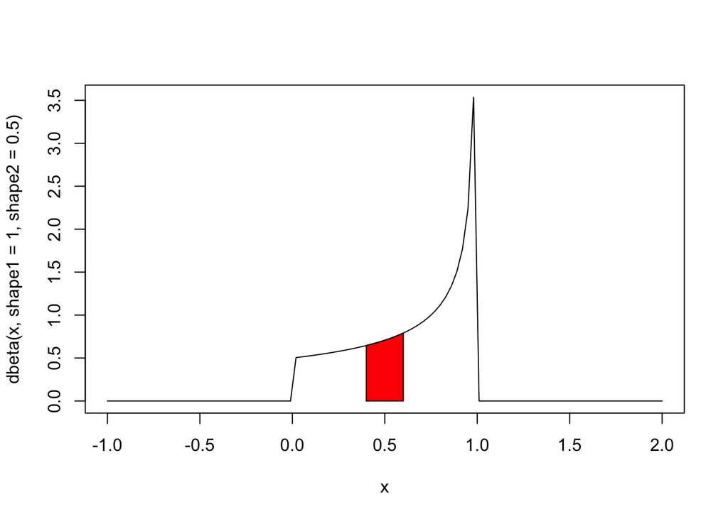

```r
x <- NULL
curve(dbeta(x, shape1 = 1, shape2 = 0.5), xlim = c(-1,2))

# Define the range of the area to highlight
xcurve <- seq(0.4, 0.6, length = 1000)

# Calculate the density of the normal distribution for this range
ycurve <- dbeta(xcurve, 1, 0.5)

polygon(c(0.4, xcurve, 0.6), c(0, ycurve, 0), col = "red")
```

```r
# Calculate the Area
area = pbeta(0.6, 1, 0.5) - pbeta(0.4, 1, 0.5)
area
```

```
## [1] 0.1421411
```

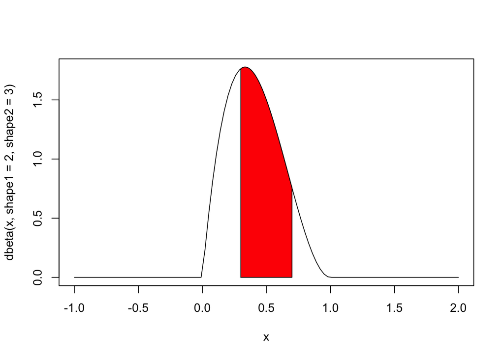

```r
x <- NULL
curve(dbeta(x, shape1 = 2, shape2 = 3), xlim = c(-1,2))

# Define the range of the area to highlight
xcurve <- seq(0.3, 0.7, length = 1000)

# Calculate the density of the normal distribution for this range
ycurve <- dbeta(xcurve, 2, 3)

polygon(c(0.3, xcurve, 0.7), c(0, ycurve, 0), col = "red")
```

```r
# Calculate the Area
area = pbeta(0.7, 2, 3) - pbeta(0.3, 2, 3)
area
```

```
## [1] 0.568
```

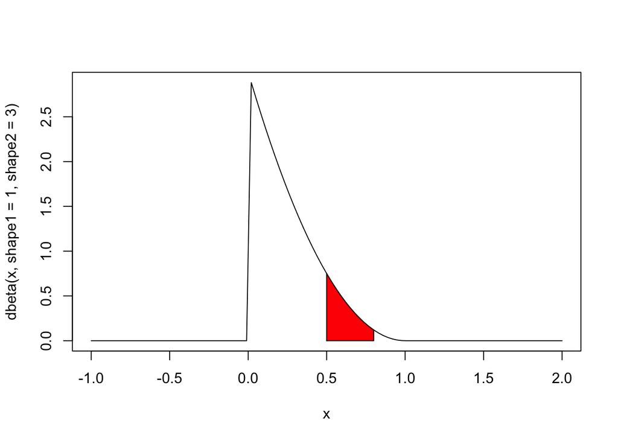

```r
x <- NULL
curve(dbeta(x, shape1 = 1, shape2 = 3), xlim = c(-1,2))

# Define the range of the area to highlight
xcurve <- seq(0.5, 0.8, length = 1000)

# Calculate the density of the normal distribution for this range
ycurve <- dbeta(xcurve, 1, 3)

polygon(c(0.5, xcurve, 0.8), c(0, ycurve, 0), col = "red")
```

```r
# Calculate the Area
area = pbeta(0.8, 1, 3) - pbeta(0.5, 1, 3)
area
```

```
## [1] 0.117
```

## Task 7

### The below is the myncurve function with an added attribute of calculating and representing the area of the function all the way up to the a that we set.

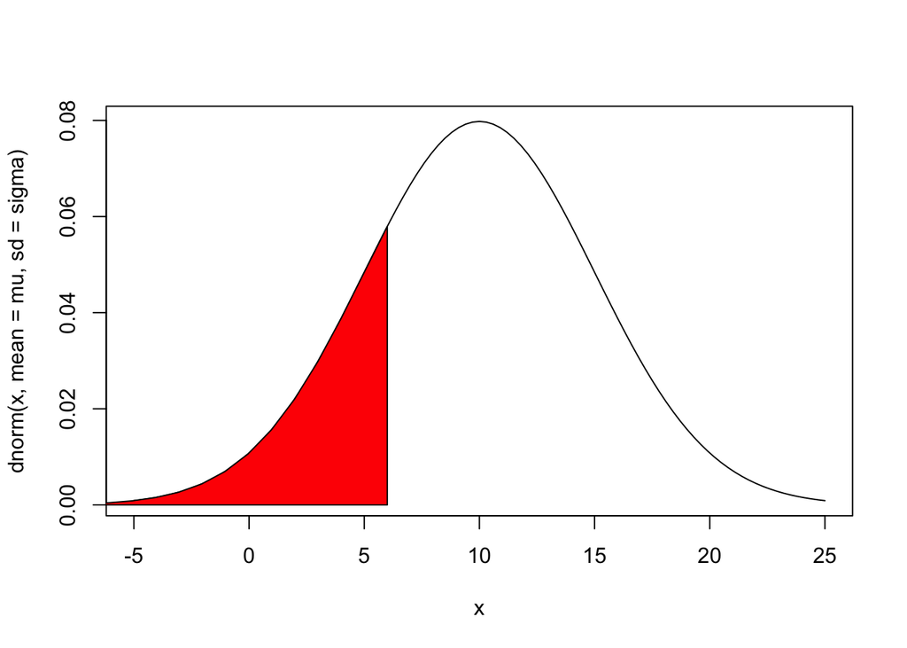

```
## [1] 0.2118554
```

```r
MATH4753DPAI24::myncurve(mu=10,sigma=5,a=6)
```

```r
1 - pnorm(20,20,6)
```

```
## [1] 0.5
```

```r
pnorm(5,10,10)
```

```
## [1] 0.3085375
```

```r
1-pnorm(0.5,0,1)
```

```
## [1] 0.3085375
```

```r
pnorm(20,20,10) - pnorm(10,20,10)
```

```
## [1] 0.3413447
```